# Señales electorales 2006–2021

## 6 Motivaciones del voto a Castillo — modelo departamental

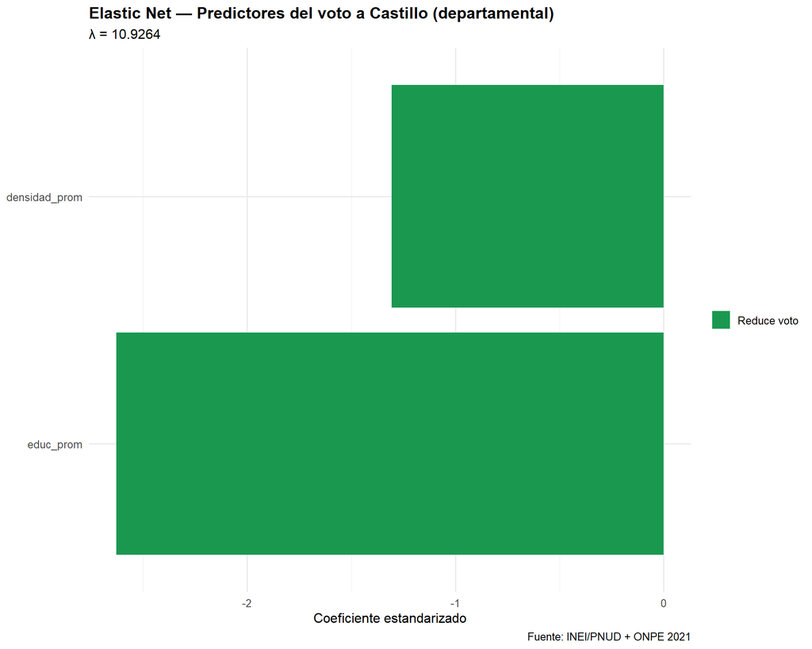

El modelo Elastic Net departamental retiene solo dos variables tras la penalización: años de educación promedio (coef = -2.629) y densidad poblacional promedio (coef = -1.307). Ambos negativos, con una interpretación sociológica precisa: Castillo obtuvo más votos en departamentos con menor escolaridad y menor densidad, es decir, en territorios rurales, dispersos y con menor acceso histórico al sistema educativo formal.

El coeficiente de educación (-2.629) es el más alto en magnitud. No significa que los votantes de Castillo fueran ignorantes: significa que los departamentos donde el sistema educativo ha fallado históricamente son precisamente donde la narrativa de Castillo — el maestro rural que conoce la exclusión desde adentro — tuvo mayor resonancia. La educación aquí es una variable de posición estructural, no de competencia cognitiva.